# BCB420 Assignment 1

Aryan Ahmad

## Setup

NOTE: Modified snippet from Lecture 4 and 5 of BCB420 Winter 2022

```r
if (!requireNamespace("BiocManager", quietly = TRUE))
  install.packages("BiocManager")
if (! requireNamespace("biomaRt", quietly = TRUE)) {
  BiocManager::install("bioMaRt")
}
if (!requireNamespace("GEOmetadb", quietly = TRUE))
  BiocManager::install("GEOmetadb")
if (! requireNamespace("edgeR", quietly = TRUE)) {
  BiocManager::install("edgeR")
}
```

## Data Loading

The first step is to load in the chosen experiment, and then put it within a dataframe to further parse

```r
#(Isserlin 2022)
#NOTE: Modified snippet from Lecture 4 and 5 of BCB420 Winter 2022
GSEID <- 'GSE112594'
sfiles = GEOquery::getGEOSuppFiles(GSEID)
fnames = rownames(sfiles)
data = read.delim(fnames[1],header=TRUE,
                       check.names = FALSE)
cols = colnames(data)
```

## Data Cleaning

#Duplicates

Next, we check if there are any possible duplicates, and take care of them. Here, no duplicates were found. There,fore no action was done.

```r
#(Isserlin 2022)
#NOTE: Modified snippet from Lecture 4 and 5 of BCB420 Winter 202
summarized_gene_counts <- sort(table(data$geneName),decreasing = TRUE)
actualGenes = unique(data$geneName)
```

#Filtering

#Genes that have low counts (at least 1 read / million) must be taken out. Approx. 45 000 were filtered here.

```r
#(Isserlin 2022)
#NOTE: Modified snippet from Lecture 4 and 5 of BCB420 Winter 202
cpms = edgeR::cpm(data[,2:196])
rownames(cpms) <- data[,1]
keep = rowSums(cpms >1) >=10
data_filtered = data[keep,]
dim(data)
```

```
## [1] 64253   196
```

```r
dim(data_filtered)
```

```
## [1] 19187   196
```

## Normalization

First, we check how the dataset looks before we do any normalization. This is done with a pre density and a pre boxplot, seen in the next 2 snippets.

### Pre-BoxPlot

Plotting just the filtered data lead to a quite uniform boxplot

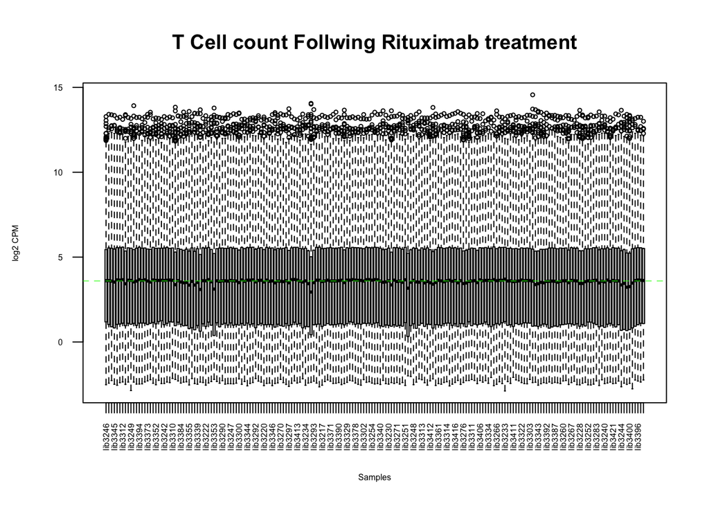

```r
#(Isserlin 2022)
#NOTE: Modified snippet from Lecture 4 and 5 of BCB420 Winter 202
data2plot <- log2(edgeR::cpm(data_filtered[,2:196]))
suppressWarnings(boxplot(data2plot, xlab = "Samples", ylab = "log2 CPM",
        las = 2, cex = 0.5, cex.lab = 0.5,
        cex.axis = 0.5, main = "T Cell count Follwing Rituximab treatment"))
abline(h = median(apply(data2plot, 2, median)),
       col = "green", lwd = 0.6, lty = "dashed")
```

### Density Plot

As we can see, this is heavily left leaning before normalization

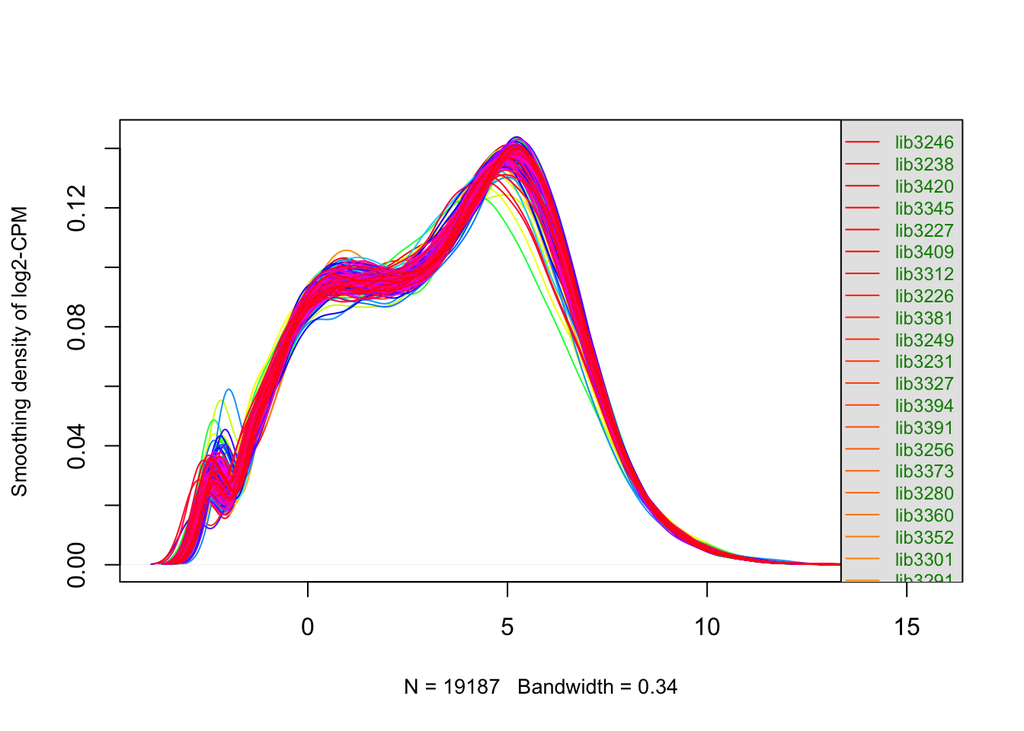

```r
#(Isserlin 2022)
#NOTE: Modified snippet from Lecture 4 and 5 of BCB420 Winter 202
counts_density <- apply(log2(edgeR::cpm(data_filtered[,2:196])),
                        2, density)

    xlim <- 0; ylim <- 0
    for (i in 1:length(counts_density)) {
      xlim <- range(c(xlim, counts_density[[i]]$x));
      ylim <- range(c(ylim, counts_density[[i]]$y))
    }
    cols <- rainbow(length(counts_density))
    ltys <- rep(1, length(counts_density))

    plot(counts_density[[1]], xlim=xlim, ylim=ylim, type="n",
         ylab="Smoothing density of log2-CPM",
         main="", cex.lab = 0.85)

    for (i in 1:length(counts_density))
      lines(counts_density[[i]], col=cols[i], lty=ltys[i])

    legend("topright", colnames(data2plot),
           col=cols, lty=ltys, cex=0.75,
           border ="blue",  text.col = "green4",
           merge = TRUE, bg = "gray90")
```

### Normalization

TMM is applied to the dataset. Note that we are comparing patients who recieved the drug vs patients who have not.

```r
#(Isserlin 2022)
#NOTE: Modified snippet from Lecture 4 and 5 of BCB420 Winter 202
filtered_data_matrix <- as.matrix(data_filtered[,2:196])
rownames(filtered_data_matrix) <- data_filtered$geneName
d = edgeR::DGEList(counts=filtered_data_matrix)
d = edgeR::calcNormFactors(d)
normalized_counts <- edgeR::cpm(d)
```

### Post Normalization Plots

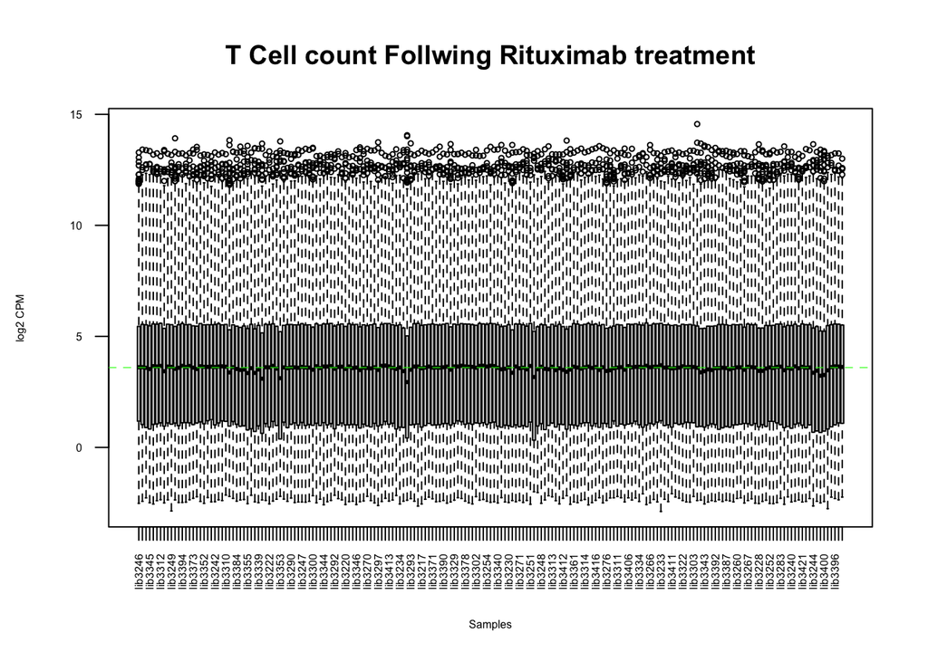

```r
#(Isserlin 2022)
#NOTE: Modified snippet from Lecture 4 and 5 of BCB420 Winter 202
data2plot <- log2(edgeR::cpm(normalized_counts))
suppressWarnings(boxplot(data2plot, xlab = "Samples", ylab = "log2 CPM",
        las = 2, cex = 0.5, cex.lab = 0.5,
        cex.axis = 0.5, main = "T Cell count Follwing Rituximab treatment"))
abline(h = median(apply(data2plot, 2, median)),
       col = "green", lwd = 0.6, lty = "dashed")
```

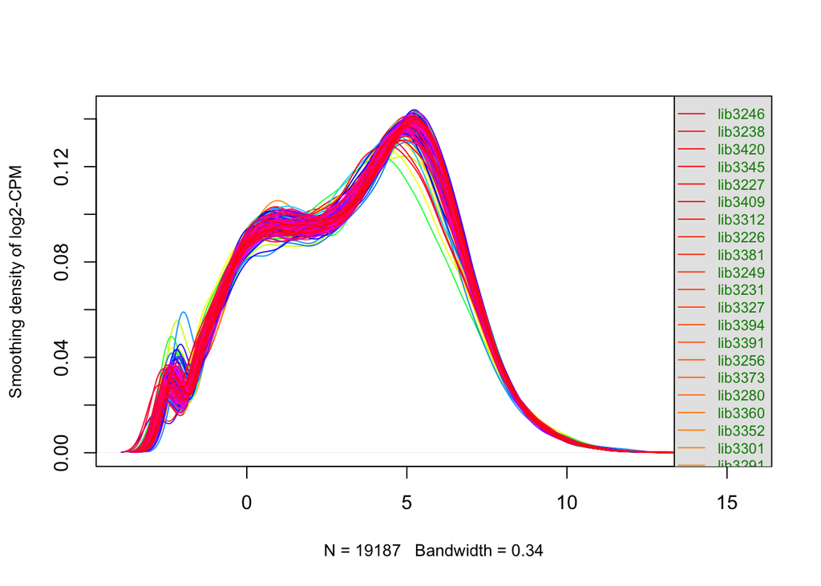

```r
counts_density <- apply(log2(edgeR::cpm(normalized_counts)),
                        2, density)

    xlim <- 0; ylim <- 0
    for (i in 1:length(counts_density)) {
      xlim <- range(c(xlim, counts_density[[i]]$x));
      ylim <- range(c(ylim, counts_density[[i]]$y))
    }
    cols <- rainbow(length(counts_density))
    ltys <- rep(1, length(counts_density))

    plot(counts_density[[1]], xlim=xlim, ylim=ylim, type="n",
         ylab="Smoothing density of log2-CPM",
         main="", cex.lab = 0.85)

    for (i in 1:length(counts_density))
      lines(counts_density[[i]], col=cols[i], lty=ltys[i])

    legend("topright", colnames(data2plot),
           col=cols, lty=ltys, cex=0.75,
           border ="blue",  text.col = "green4",
           merge = TRUE, bg = "gray90")
```

```r
#(Isserlin 2022)
#NOTE: Modified snippet from Lecture 4 and 5 of BCB420 Winter 202
#edgeR::plotMDS.DGEList(d, labels=rownames(data_filtered),
#  col = c("orange","yellow")[factor(data_filtered$geneName)])
```

## Mapping to HUGO

Here the human ensembl genes are compared to against the HUGO gene symbols. They are compared against one other, then the HUGE symboles replace the ensembl ones.

```r
#(Isserlin 2022)
#NOTE: Modified snippet from Lecture 4 and 5 of BCB420 Winter 202
ensembl <- biomaRt::useMart("ensembl", dataset = "hsapiens_gene_ensembl")
conversion_stash <- "data_conv.rds"
data_conv <- biomaRt::getBM(attributes = c("ensembl_gene_id","hgnc_symbol"),
                            filters = c("ensembl_gene_id"),
                            values = data$geneName,
                            mart = ensembl)
difference <- nrow(data) - nrow(data_conv)
difference
```

```
## [1] 4363
```

```r
#The commented code below seems to crash my computer

#data_annot <- merge(data_conv, data)

#difference_annot <- nrow(data_annot) - nrow(data)
#difference_annot
```

## Discussion

### What are the control and test conditions of the dataset?

The control group is the group that did not recieve rituximab, while the test group did.

### Why is the dataset of interest to you?

A family member suffers from T1D, which is why the overall topic chosen was related to this. This medicine, rituximab, has recently been in the news as a potential cancer treatment for a type of lymphoma.

### Were there expression values that could not be mapped to current HUGO symbols?

Yes, the number of expression values were 4363 genes.

### How many outliers were removed?

No outliers needed to be removed.

### How did you handle replicates?

# References

Isserlin, R. (2022). Lecture 4 - Data Exploration and Normalization. Retrieved from Quercus website: https://q.utoronto.ca/courses/248455/files/19273570?module_item_id=3476594

Isserlin, R. (2022). Lecture 5 - Data Exploration and ID Mapping. Retrieved from Quercus website: https://q.utoronto.ca/courses/248455/files/18120883?module_item_id=3463354

Linsley, P. S., Greenbaum, C. J., Rosasco, M., Presnell, S., Herold, K. C., & Dufort, M. J. (2019). Elevated T cell levels in peripheral blood predict poor clinical response following rituximab treatment in new-onset type 1 diabetes. Genes and Immunity, 20(4), 293–307. doi:10.1038/s41435-018-0032-1

Linsley PS, Greenbaum CJ, Rosasco MG, Presnell SR, Herold KC, Dufort MJ. (2018, May 12). Elevated T cell levels in peripheral blood predict poor clinical response following rituximab treatment in new-onset type 1 diabetes. Retrieved from Nih.gov website: https://www.ncbi.nlm.nih.gov/geo/query/acc.cgi